# Articulatory Analysis

Tabea Thies

2022-09-13

# Comparing levoDOPA and DBS effect on tongue body movements

Load necessary packages

```r
library(tidyverse)
library(ggplot2)
library(lme4)
library(lmerTest)
library(merTools)
library(sjPlot)
library(sjmisc)
```

Load data set

```r
data <- read_csv('../data/articulation.csv')
```

Create subset for the comparison med-OFF vs med-ON vs DBS-ON

med-OFF functions as baseline here

```r
data_red <-  filter(data, med_con %in% c('med-OFF', 'med-ON', 'med-OFF/DBS-ON'))

## second subset for stats

data_red2 <-  filter(data, med_con %in% c('med-OFF', 'med-OFF/DBS-ON'))
```

# Movement duration

Descriptive stats for reporting values in Section 9.2.3

```r
DUR_stats <- data_red %>%
  group_by(med_con) %>%
  summarise(M = round(mean(GAI_V1)),
            SD = round(sd(GAI_V1)))
DUR_stats
```

```
## # A tibble: 3 x 3
##   med_con            M    SD
##   <chr>          <dbl> <dbl>
## 1 med-OFF          194    46
## 2 med-OFF/DBS-ON   199    54
## 3 med-ON           187    47
```

```r
DUR_stats2 <- data_red %>%
  group_by(med_con, focus_con) %>%
  summarise(M = round(mean(GAI_V1)),
            SD = round(sd(GAI_V1)))
DUR_stats2
```

```
## # A tibble: 9 x 4
## # Groups:   med_con [3]
##   med_con        focus_con       M    SD
##   <chr>          <chr>       <dbl> <dbl>
## 1 med-OFF        background    186    43
## 2 med-OFF        broad         193    45
## 3 med-OFF        contrastive   203    49
## 4 med-OFF/DBS-ON background    189    52
## 5 med-OFF/DBS-ON broad         202    55
## 6 med-OFF/DBS-ON contrastive   206    53
## 7 med-ON         background    180    42
## 8 med-ON         broad         188    45
## 9 med-ON         contrastive   193    53
```

Plot tongue body movement duration

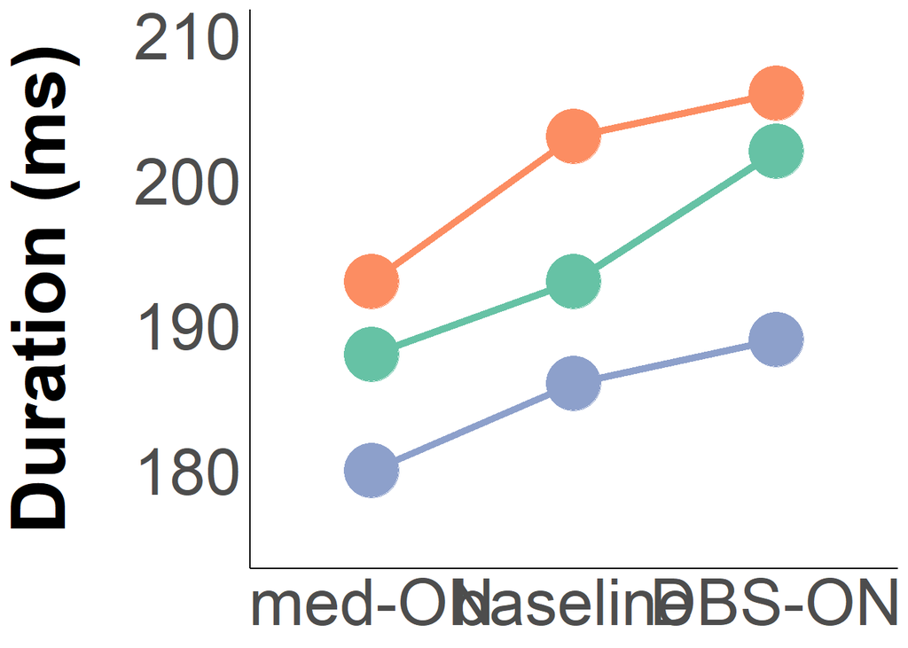

```r
DUR_stats2 %>%
  ggplot(aes(x=factor(med_con, level = c("med-ON", "med-OFF", "med-OFF/DBS-ON")), y=M, group = focus_con, col=focus_con)) +
  geom_line(size = 2) +
  geom_point(size = 14)+
  theme_classic() +
  theme(legend.position = 'none')+
  theme(legend.title = element_blank(),
        legend.text = element_text(size = 36))+
  scale_color_manual(values = c("#8da0cb", "#66c2a5", "#fc8d62")) +
  xlab(NULL) +
  scale_x_discrete(labels = c('med-ON','baseline', "DBS-ON"))+
  coord_cartesian(ylim = c(175, 210)) +
  scale_y_continuous(breaks = seq(180, 210, 10)) +
  ylab("Duration (ms)")+
  theme(axis.title.y = element_text(face = 'bold', size = 42, margin = margin(r = 30)))+
  theme(strip.text.x = element_text(size=38, face="bold"),
        strip.background = element_blank())+
  theme(axis.text.x = element_text(size = 36),
        axis.text.y = element_text(size = 36)) +
  theme(axis.ticks.x = element_blank(),
        axis.ticks.y = element_blank())
```

Create linear mixed model to investigate effect on TB duration

```r
mdl <- lmer(GAI_V1 ~ med_con + focus_con + vowel + cons + age  + (1 + focus_con+med_con|speaker), data_red2, REML = FALSE)
```

Look at model summary

```r
summary(mdl)
```

```
## Linear mixed model fit by maximum likelihood . t-tests use Satterthwaite's
##   method [lmerModLmerTest]
## Formula: GAI_V1 ~ med_con + focus_con + vowel + cons + age + (1 + focus_con +
##     med_con | speaker)
##    Data: data_red2
##
##      AIC      BIC   logLik deviance df.resid
##   7885.3   7983.3  -3921.7   7843.3      764
##
## Scaled residuals:
##     Min      1Q  Median      3Q     Max
## -3.1431 -0.6784 -0.0373  0.6461  3.6168
##
## Random effects:
##  Groups   Name                  Variance  Std.Dev. Corr
##  speaker  (Intercept)           7.338e+02 27.0884
##           focus_conbroad        5.144e-02  0.2268   0.37
##           focus_concontrastive  1.002e+01  3.1661   0.67 -0.14
##           med_conmed-OFF/DBS-ON 6.982e+02 26.4238   0.04 -0.64  0.76
##  Residual                       1.157e+03 34.0079
## Number of obs: 785, groups:  speaker, 13
##
## Fixed effects:
##                       Estimate Std. Error       df t value Pr(>|t|)
## (Intercept)           125.0623    56.3816  13.4387   2.218  0.04434 *
## med_conmed-OFF/DBS-ON   3.4302     7.7619  13.2664   0.442  0.66566
## focus_conbroad          9.5017     2.9706 701.8336   3.199  0.00144 **
## focus_concontrastive   16.6517     3.0993  70.8348   5.373 9.40e-07 ***
## vowele                -18.3418     3.8334 758.4141  -4.785 2.06e-06 ***
## voweli                -15.6456     3.8458 758.4371  -4.068 5.23e-05 ***
## vowelo                -15.2367     3.8517 758.4114  -3.956 8.34e-05 ***
## vowelu                -28.5039     3.8452 758.3939  -7.413 3.31e-13 ***
## conslab               -14.2715     2.4283 758.4264  -5.877 6.25e-09 ***
## age                     1.4118     0.9463  13.3590   1.492  0.15896
## ---
## Signif. codes:  0 '***' 0.001 '**' 0.01 '*' 0.05 '.' 0.1 ' ' 1
##
## Correlation of Fixed Effects:
##             (Intr) m_-OFF fcs_cnb fcs_cnc vowele voweli vowelo vowelu conslb
## m_-OFF/DBS-  0.100
## focus_cnbrd -0.025 -0.013
## fcs_cncntrs -0.001  0.202  0.476
## vowele      -0.036  0.003  0.007   0.007
## voweli      -0.030  0.000  0.007   0.005   0.503
## vowelo      -0.031  0.001  0.010   0.005   0.502  0.501
## vowelu      -0.034  0.002  0.007   0.005   0.503  0.502  0.501
## conslab     -0.024  0.002  0.007   0.006  -0.002 -0.010 -0.008 -0.006
## age         -0.989 -0.103 -0.001   0.001   0.001 -0.005 -0.003 -0.001  0.002
## optimizer (nloptwrap) convergence code: 0 (OK)
## Model failed to converge with max|grad| = 0.0133835 (tol = 0.002, component 1)
```

extracting fit statistics for reporting in text

```r
tab_model(mdl)
```

|  | GAI V 1 |  |  |
| --- | --- | --- | --- |
| Predictors | Estimates | CI | p |
| (Intercept) | 125.06 | 14.38 – 235.74 | **0.027** |
| med con [med-OFF/DBS-ON] | 3.43 | -11.81 – 18.67 | 0.659 |
| focus con [broad] | 9.50 | 3.67 – 15.33 | **0.001** |
| focus con [contrastive] | 16.65 | 10.57 – 22.74 | **<0.001** |
| vowel [e] | -18.34 | -25.87 – -10.82 | **<0.001** |
| vowel [i] | -15.65 | -23.20 – -8.10 | **<0.001** |
| vowel [o] | -15.24 | -22.80 – -7.68 | **<0.001** |
| vowel [u] | -28.50 | -36.05 – -20.96 | **<0.001** |
| cons [lab] | -14.27 | -19.04 – -9.50 | **<0.001** |
| age | 1.41 | -0.45 – 3.27 | 0.136 |
| Random Effects |  |  |  |
| σ<sup>2</sup> | 1156.54 |  |  |
| τ<sub>00</sub> <sub>speaker</sub> | 733.78 |  |  |
| τ<sub>11</sub> <sub>speaker.focus_conbroad</sub> | 0.05 |  |  |
| τ<sub>11</sub> <sub>speaker.focus_concontrastive</sub> | 10.02 |  |  |
| τ<sub>11</sub> <sub>speaker.med_conmed-OFF/DBS-ON</sub> | 698.22 |  |  |
| ρ<sub>01</sub> | 0.37 |  |  |
|  | 0.67 |  |  |
|  | 0.04 |  |  |
| ICC | 0.50 |  |  |
| N <sub>speaker</sub> | 13 |  |  |
| Observations | 785 |  |  |
| Marginal R<sup>2</sup> / Conditional R<sup>2</sup> | 0.121 / 0.564 |  |  |

## Explore random effects with function REsim

Effects for individual levels are simulated  
Output: mean, median and sd of the random effect estimates

Plots estimated random effects for each participant  
95 % Intervals that do not overlap zero are bold

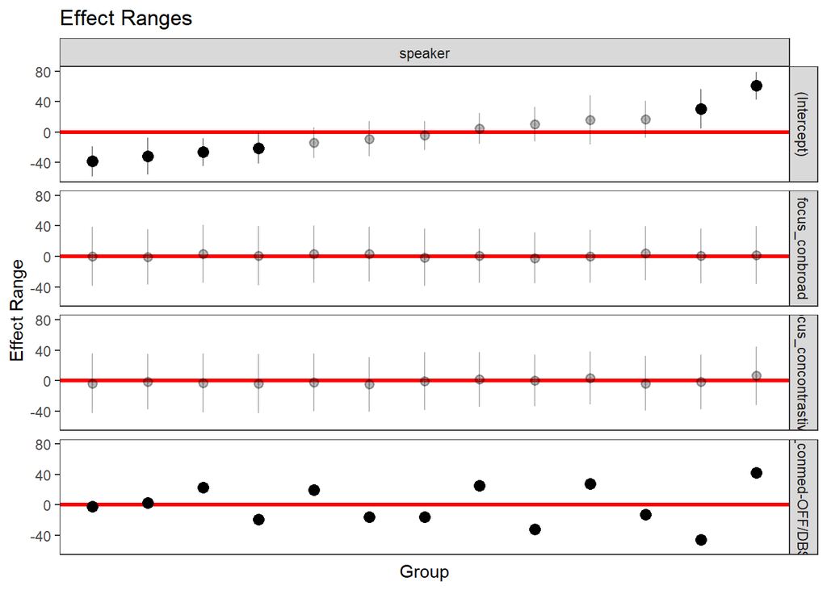

```r
randoms <- REsim(mdl)
plotREsim(randoms)
```

Plot estimated 95 % interval spans for the intercept of TB duration

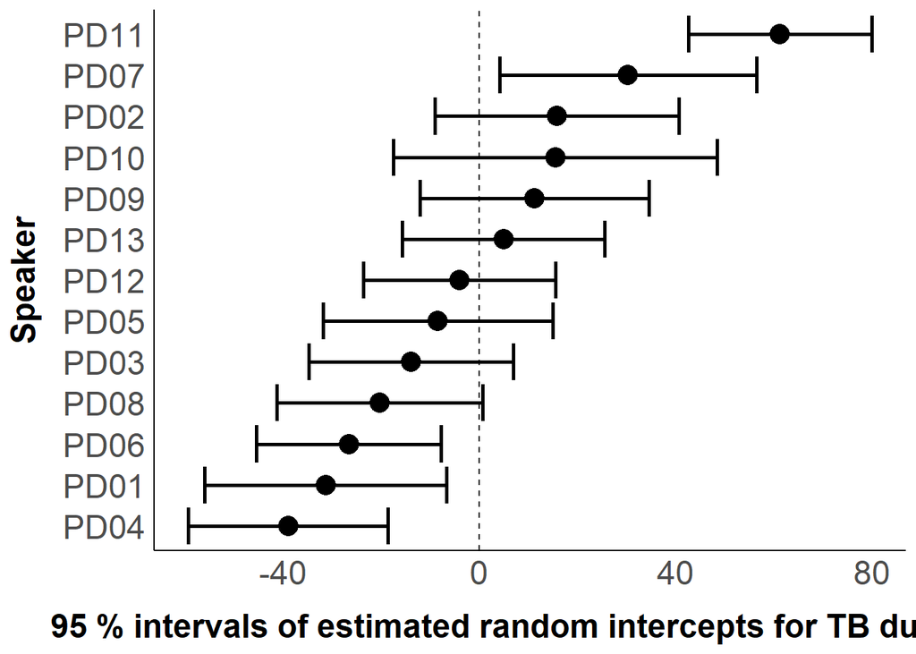

```r
random2 <- subset(randoms, term == "(Intercept)")

random2 %>%
  ggplot(aes(x = mean, xmin = mean-sd-sd, xmax = mean+sd+sd, y = reorder(groupID, mean))) +
  geom_vline(xintercept = 0, linetype = 'dashed') +
  geom_point(size = 5)+
  geom_errorbar(size = 1) +
  theme_classic()+
  xlab('95 % intervals of estimated random intercepts for TB duration') +
  ylab('Speaker')+
  theme(axis.title.y = element_text(face = 'bold', size = 18, margin = margin(r = 12)))+
  theme(axis.title.x = element_text(face = 'bold', size = 18, margin = margin(t = 12)))+
  theme(strip.text.x = element_text(size=18, face="bold"),
        strip.background = element_blank())+
  theme(axis.text.x = element_text(size = 18),
        axis.text.y = element_text(size = 18)) +
  theme(axis.ticks.x = element_blank(),
        axis.ticks.y = element_blank())+
  theme(legend.position = "top",
        legend.title = element_blank(),
        legend.text = element_text(size = 18))
```

Plot estimated 95 % interval spans for the slope of TB duration

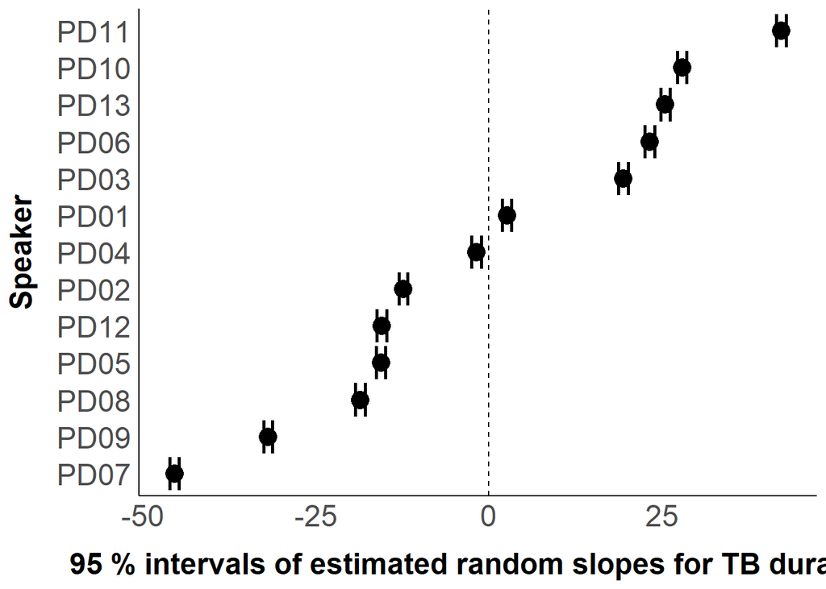

```r
random3 <- subset(randoms, term == "med_conmed-OFF/DBS-ON")

random3 %>%
  ggplot(aes(x = mean, xmin = mean-sd-sd, xmax = mean+sd+sd, y = reorder(groupID, mean))) +
  geom_vline(xintercept = 0, linetype = 'dashed') +
  geom_point(size = 5)+
  geom_errorbar(size = 1) +
  theme_classic()+
  xlab('95 % intervals of estimated random slopes for TB duration') +
  ylab('Speaker')+
  theme(axis.title.y = element_text(face = 'bold', size = 18, margin = margin(r = 12)))+
  theme(axis.title.x = element_text(face = 'bold', size = 18, margin = margin(t = 12)))+
  theme(strip.text.x = element_text(size=18, face="bold"),
        strip.background = element_blank())+
  theme(axis.text.x = element_text(size = 18),
        axis.text.y = element_text(size = 18)) +
  theme(axis.ticks.x = element_blank(),
        axis.ticks.y = element_blank())+
  theme(legend.position = "top",
        legend.title = element_blank(),
        legend.text = element_text(size = 18))
```

# Movement amplitude

Descriptive stats for reporting values in Section 10.2.3

```r
DISPL_stats <- data_red %>%
  group_by(med_con) %>%
  summarise(M = round(mean(disp_V1_abs),1),
            SD = round(sd(disp_V1_abs),1))
DISPL_stats
```

```
## # A tibble: 3 x 3
##   med_con            M    SD
##   <chr>          <dbl> <dbl>
## 1 med-OFF          7.8   4.5
## 2 med-OFF/DBS-ON   7.1   4.6
## 3 med-ON           7.5   4.4
```

```r
DISPL_stats2 <- data_red %>%
  group_by(med_con, focus_con) %>%
  summarise(M = round(mean(disp_V1_abs),1),
            SD = round(sd(disp_V1_abs),1))
DISPL_stats2
```

```
## # A tibble: 9 x 4
## # Groups:   med_con [3]
##   med_con        focus_con       M    SD
##   <chr>          <chr>       <dbl> <dbl>
## 1 med-OFF        background    7.4   4.2
## 2 med-OFF        broad         7.9   4.5
## 3 med-OFF        contrastive   8     4.8
## 4 med-OFF/DBS-ON background    6.8   4.4
## 5 med-OFF/DBS-ON broad         7.2   4.6
## 6 med-OFF/DBS-ON contrastive   7.3   4.8
## 7 med-ON         background    7.2   4.2
## 8 med-ON         broad         7.5   4.5
## 9 med-ON         contrastive   7.9   4.5
```

Plot tongue body movement amplitude

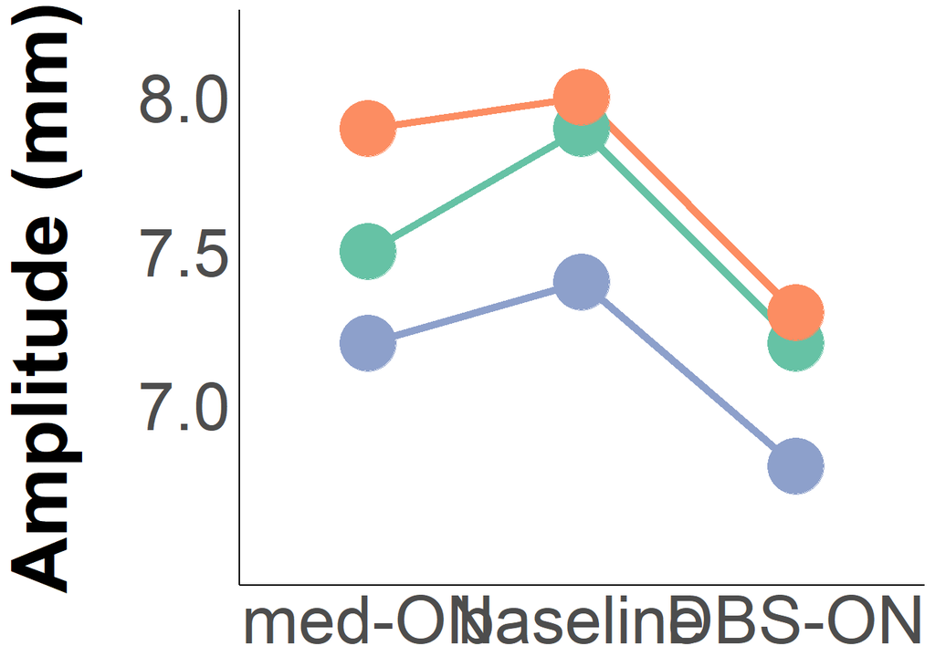

```r
DISPL_stats2 %>%
  ggplot(aes(x=factor(med_con, level = c("med-ON", "med-OFF", "med-OFF/DBS-ON")), y=M, group = focus_con, col=focus_con)) +
  geom_line(size = 2) +
  geom_point(size = 14)+
  theme_classic() +
  theme(legend.position = 'none')+
  theme(legend.title = element_blank(),
        legend.text = element_text(size = 36))+
  scale_color_manual(values = c("#8da0cb", "#66c2a5", "#fc8d62")) +
  coord_cartesian(ylim = c(6.5, 8.2)) +
  scale_y_continuous(breaks = seq(7, 8, 0.5)) +
  xlab(NULL) +
  scale_x_discrete(labels = c('med-ON','baseline', "DBS-ON"))+
  ylab("Amplitude (mm)")+
  theme(axis.title.y = element_text(face = 'bold', size = 42, margin = margin(r = 30)))+
  theme(strip.text.x = element_text(size=38, face="bold"),
        strip.background = element_blank())+
  theme(axis.text.x = element_text(size = 36),
        axis.text.y = element_text(size = 36)) +
  theme(axis.ticks.x = element_blank(),
        axis.ticks.y = element_blank())
```

Create linear mixed model to investigate effect on TB amplitude

```r
mdl2 <- lmer(disp_V1_abs ~ med_con + focus_con + vowel + cons + age  + (1 + focus_con+med_con|speaker), data_red2, REML = FALSE)
```

Look at model summary

```r
summary(mdl2)
```

```
## Linear mixed model fit by maximum likelihood . t-tests use Satterthwaite's
##   method [lmerModLmerTest]
## Formula: disp_V1_abs ~ med_con + focus_con + vowel + cons + age + (1 +
##     focus_con + med_con | speaker)
##    Data: data_red2
##
##      AIC      BIC   logLik deviance df.resid
##   3649.9   3747.9  -1803.9   3607.9      764
##
## Scaled residuals:
##     Min      1Q  Median      3Q     Max
## -3.0942 -0.6497 -0.0210  0.6662  3.3424
##
## Random effects:
##  Groups   Name                  Variance Std.Dev. Corr
##  speaker  (Intercept)           1.43210  1.1967
##           focus_conbroad        0.01215  0.1102   1.00
##           focus_concontrastive  0.01781  0.1335   0.97 0.97
##           med_conmed-OFF/DBS-ON 2.63499  1.6233   0.30 0.30 0.08
##  Residual                       5.32974  2.3086
## Number of obs: 785, groups:  speaker, 13
##
## Fixed effects:
##                        Estimate Std. Error        df t value Pr(>|t|)
## (Intercept)             4.71443    2.64230  13.52811   1.784 0.096824 .
## med_conmed-OFF/DBS-ON  -0.86272    0.48090  13.12215  -1.794 0.095883 .
## focus_conbroad          0.41181    0.20391 208.70945   2.020 0.044705 *
## focus_concontrastive    0.51020    0.20513 150.18004   2.487 0.013969 *
## vowele                 -7.95747    0.26023 759.01216 -30.579  < 2e-16 ***
## voweli                 -6.40011    0.26106 759.04495 -24.516  < 2e-16 ***
## vowelo                 -5.25342    0.26147 759.00552 -20.092  < 2e-16 ***
## vowelu                -10.42928    0.26103 758.98257 -39.955  < 2e-16 ***
## conslab                 0.60112    0.16485 759.02449   3.647 0.000284 ***
## age                     0.14447    0.04429  13.37907   3.262 0.005983 **
## ---
## Signif. codes:  0 '***' 0.001 '**' 0.01 '*' 0.05 '.' 0.1 ' ' 1
##
## Correlation of Fixed Effects:
##             (Intr) m_-OFF fcs_cnb fcs_cnc vowele voweli vowelo vowelu conslb
## m_-OFF/DBS-  0.101
## focus_cnbrd -0.019  0.042
## fcs_cncntrs -0.016  0.013  0.510
## vowele      -0.051  0.003  0.007   0.007
## voweli      -0.043  0.000  0.007   0.005   0.503
## vowelo      -0.044  0.002  0.010   0.005   0.502  0.501
## vowelu      -0.048  0.002  0.007   0.005   0.503  0.502  0.501
## conslab     -0.035  0.002  0.007   0.006  -0.002 -0.010 -0.008 -0.006
## age         -0.988 -0.078  0.000   0.000   0.000 -0.007 -0.006 -0.002  0.003
## optimizer (nloptwrap) convergence code: 0 (OK)
## boundary (singular) fit: see help('isSingular')
```

extracting fit statistics for reporting in text

```r
tab_model(mdl2)
```

|  | disp V 1 abs |  |  |
| --- | --- | --- | --- |
| Predictors | Estimates | CI | p |
| (Intercept) | 4.71 | -0.47 – 9.90 | 0.075 |
| med con [med-OFF/DBS-ON] | -0.86 | -1.81 – 0.08 | 0.073 |
| focus con [broad] | 0.41 | 0.01 – 0.81 | **0.044** |
| focus con [contrastive] | 0.51 | 0.11 – 0.91 | **0.013** |
| vowel [e] | -7.96 | -8.47 – -7.45 | **<0.001** |
| vowel [i] | -6.40 | -6.91 – -5.89 | **<0.001** |
| vowel [o] | -5.25 | -5.77 – -4.74 | **<0.001** |
| vowel [u] | -10.43 | -10.94 – -9.92 | **<0.001** |
| cons [lab] | 0.60 | 0.28 – 0.92 | **<0.001** |
| age | 0.14 | 0.06 – 0.23 | **0.001** |
| Random Effects |  |  |  |
| σ<sup>2</sup> | 5.33 |  |  |
| τ<sub>00</sub> <sub>speaker</sub> | 1.43 |  |  |
| τ<sub>11</sub> <sub>speaker.focus_conbroad</sub> | 0.01 |  |  |
| τ<sub>11</sub> <sub>speaker.focus_concontrastive</sub> | 0.02 |  |  |
| τ<sub>11</sub> <sub>speaker.med_conmed-OFF/DBS-ON</sub> | 2.63 |  |  |
| ρ<sub>01</sub> | 1.00 |  |  |
|  | 0.97 |  |  |
|  | 0.30 |  |  |
| N <sub>speaker</sub> | 13 |  |  |
| Observations | 785 |  |  |
| Marginal R<sup>2</sup> / Conditional R<sup>2</sup> | 0.719 / NA |  |  |

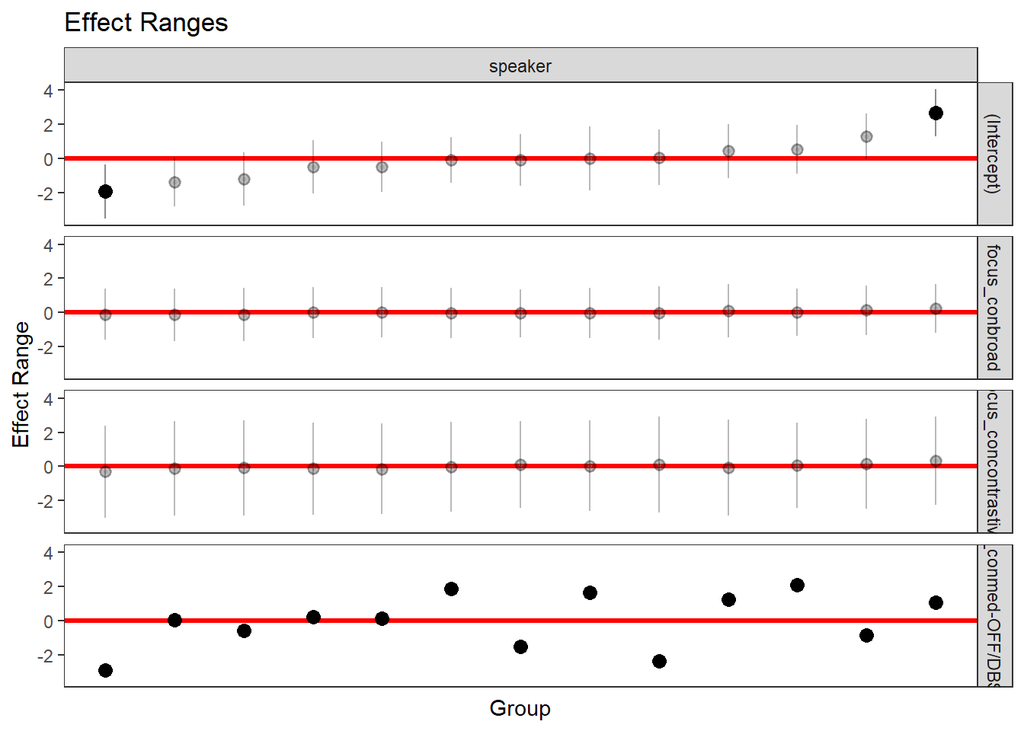

```r
randoms <- REsim(mdl2)
plotREsim(randoms)
```

Plot estimated 95 % interval spans for the intercept of TB amplitude

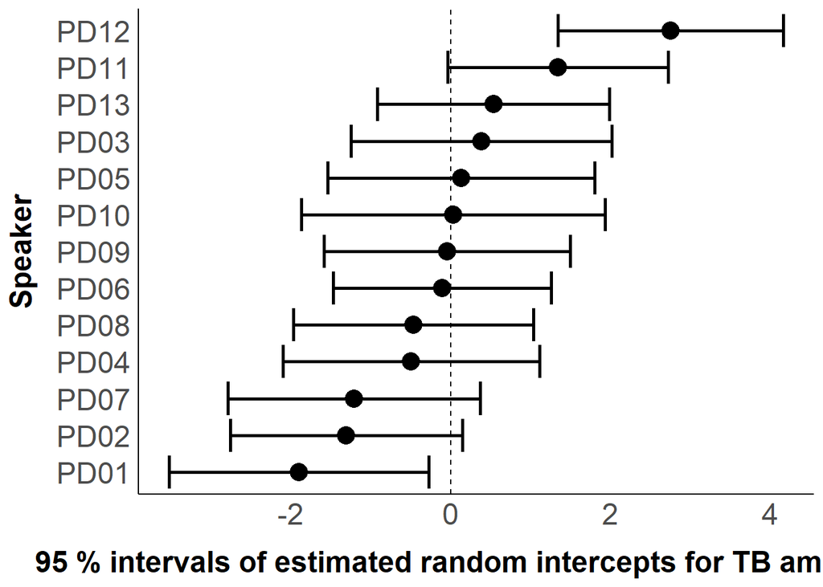

```r
random2 <- subset(randoms, term == "(Intercept)")

random2 %>%
  ggplot(aes(x = mean, xmin = mean-sd-sd, xmax = mean+sd+sd, y = reorder(groupID, mean))) +
  geom_vline(xintercept = 0, linetype = 'dashed') +
  geom_point(size = 5)+
  geom_errorbar(size = 1) +
  theme_classic()+
  xlab('95 % intervals of estimated random intercepts for TB amplitude') +
  ylab('Speaker')+
  theme(axis.title.y = element_text(face = 'bold', size = 18, margin = margin(r = 12)))+
  theme(axis.title.x = element_text(face = 'bold', size = 18, margin = margin(t = 12)))+
  theme(strip.text.x = element_text(size=18, face="bold"),
        strip.background = element_blank())+
  theme(axis.text.x = element_text(size = 18),
        axis.text.y = element_text(size = 18)) +
  theme(axis.ticks.x = element_blank(),
        axis.ticks.y = element_blank())+
  theme(legend.position = "top",
        legend.title = element_blank(),
        legend.text = element_text(size = 18))
```

Plot estimated 95 % interval spans for the slopes of TB amplitude

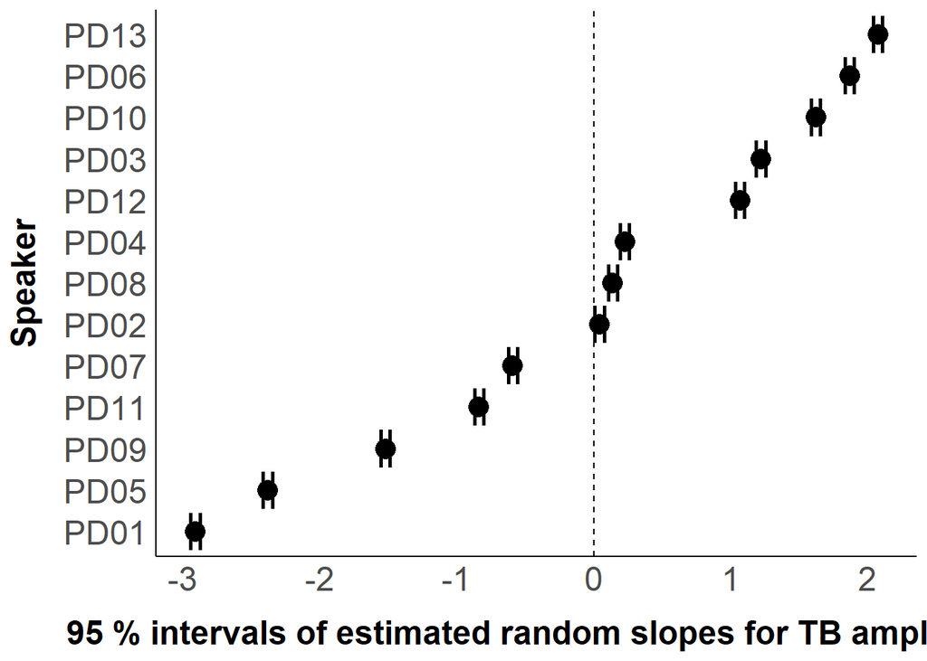

```r
random3 <- subset(randoms, term == "med_conmed-OFF/DBS-ON")

random3 %>%
  ggplot(aes(x = mean, xmin = mean-sd-sd, xmax = mean+sd+sd, y = reorder(groupID, mean))) +
  geom_vline(xintercept = 0, linetype = 'dashed') +
  geom_point(size = 5)+
  geom_errorbar(size = 1) +
  theme_classic()+
  xlab('95 % intervals of estimated random slopes for TB amplitude') +
  ylab('Speaker')+
  theme(axis.title.y = element_text(face = 'bold', size = 18, margin = margin(r = 12)))+
  theme(axis.title.x = element_text(face = 'bold', size = 18, margin = margin(t = 12)))+
  theme(strip.text.x = element_text(size=18, face="bold"),
        strip.background = element_blank())+
  theme(axis.text.x = element_text(size = 18),
        axis.text.y = element_text(size = 18)) +
  theme(axis.ticks.x = element_blank(),
        axis.ticks.y = element_blank())+
  theme(legend.position = "top",
        legend.title = element_blank(),
        legend.text = element_text(size = 18))
```

# Movement peak velocities

Descriptive stats for reporting values in Section 10.2.3

```r
PVEL_stats <- data_red %>%
  group_by(med_con) %>%
  summarise(M = round(mean(pvel_V1_abs)),
            SD = round(sd(pvel_V1_abs)))
PVEL_stats
```

```
## # A tibble: 3 x 3
##   med_con            M    SD
##   <chr>          <dbl> <dbl>
## 1 med-OFF           74    41
## 2 med-OFF/DBS-ON    67    40
## 3 med-ON            77    44
```

```r
PVEL_stats2 <- data_red %>%
  group_by(med_con, focus_con) %>%
  summarise(M = round(mean(pvel_V1_abs)),
            SD = round(sd(pvel_V1_abs)))
PVEL_stats2
```

```
## # A tibble: 9 x 4
## # Groups:   med_con [3]
##   med_con        focus_con       M    SD
##   <chr>          <chr>       <dbl> <dbl>
## 1 med-OFF        background     72    41
## 2 med-OFF        broad          76    39
## 3 med-OFF        contrastive    75    42
## 4 med-OFF/DBS-ON background     67    38
## 5 med-OFF/DBS-ON broad          66    40
## 6 med-OFF/DBS-ON contrastive    68    42
## 7 med-ON         background     75    44
## 8 med-ON         broad          77    45
## 9 med-ON         contrastive    80    42
```

Create linear mixed model to investigate disease effect on TB velocity

```r
mdl3 <- lmer(pvel_V1_abs ~ med_con + focus_con + vowel + cons + age  + (1 + focus_con+med_con|speaker), data_red, REML = FALSE)
```

Look at model summary

```r
summary(mdl3)
```

```
## Linear mixed model fit by maximum likelihood . t-tests use Satterthwaite's
##   method [lmerModLmerTest]
## Formula: pvel_V1_abs ~ med_con + focus_con + vowel + cons + age + (1 +
##     focus_con + med_con | speaker)
##    Data: data_red
##
##      AIC      BIC   logLik deviance df.resid
##  10892.5  11029.4  -5419.2  10838.5     1150
##
## Scaled residuals:
##     Min      1Q  Median      3Q     Max
## -5.3904 -0.5983 -0.0260  0.5909  8.2760
##
## Random effects:
##  Groups   Name                  Variance Std.Dev. Corr
##  speaker  (Intercept)           197.623  14.058
##           focus_conbroad          4.343   2.084   -0.13
##           focus_concontrastive   30.320   5.506    0.09  0.83
##           med_conmed-OFF/DBS-ON 234.114  15.301   -0.11 -0.25  0.04
##           med_conmed-ON          58.095   7.622    0.11 -0.77 -0.32  0.67
##  Residual                       541.167  23.263
## Number of obs: 1177, groups:  speaker, 13
##
## Fixed effects:
##                        Estimate Std. Error        df t value Pr(>|t|)
## (Intercept)             68.1673    29.1888   13.3877   2.335   0.0357 *
## med_conmed-OFF/DBS-ON   -7.9576     4.5759   13.2145  -1.739   0.1053
## med_conmed-ON            3.2610     2.6891   13.1214   1.213   0.2466
## focus_conbroad           1.3323     1.7569   49.2824   0.758   0.4519
## focus_concontrastive     2.1296     2.2556   13.4040   0.944   0.3618
## vowele                 -68.0210     2.1338 1126.0378 -31.878   <2e-16 ***
## voweli                 -49.3567     2.1561 1125.9122 -22.892   <2e-16 ***
## vowelo                 -35.4433     2.1510 1125.5570 -16.478   <2e-16 ***
## vowelu                 -82.0817     2.1486 1125.4702 -38.202   <2e-16 ***
## conslab                 13.0659     1.3565 1125.6819   9.632   <2e-16 ***
## age                      0.7738     0.4896   13.2614   1.581   0.1375
## ---
## Signif. codes:  0 '***' 0.001 '**' 0.01 '*' 0.05 '.' 0.1 ' ' 1
##
## Correlation of Fixed Effects:
##             (Intr) m_-OFF md_-ON fcs_cnb fcs_cnc vowele voweli vowelo vowelu
## m_-OFF/DBS-  0.065
## med_cnmd-ON -0.007  0.600
## focus_cnbrd -0.032 -0.076 -0.199
## fcs_cncntrs -0.014  0.027 -0.173  0.531
## vowele      -0.038  0.003 -0.001  0.005   0.005
## voweli      -0.034  0.000  0.003  0.008   0.004   0.502
## vowelo      -0.035  0.001  0.001  0.006   0.002   0.504  0.499
## vowelu      -0.037  0.002  0.002  0.005   0.002   0.505  0.499  0.501
## conslab     -0.024  0.002  0.004  0.003   0.001   0.000 -0.005 -0.005 -0.004
## age         -0.988 -0.090  0.001  0.000   0.001   0.001 -0.003 -0.002  0.000
##             conslb
## m_-OFF/DBS-
## med_cnmd-ON
## focus_cnbrd
## fcs_cncntrs
## vowele
## voweli
## vowelo
## vowelu
## conslab
## age          0.001
```

extracting fit statistics for reporting in text

```r
tab_model(mdl3)
```

|  | pvel V 1 abs |  |  |
| --- | --- | --- | --- |
| Predictors | Estimates | CI | p |
| (Intercept) | 68.17 | 10.90 – 125.44 | **0.020** |
| med con [med-OFF/DBS-ON] | -7.96 | -16.94 – 1.02 | 0.082 |
| med con [med-ON] | 3.26 | -2.02 – 8.54 | 0.225 |
| focus con [broad] | 1.33 | -2.11 – 4.78 | 0.448 |
| focus con [contrastive] | 2.13 | -2.30 – 6.56 | 0.345 |
| vowel [e] | -68.02 | -72.21 – -63.83 | **<0.001** |
| vowel [i] | -49.36 | -53.59 – -45.13 | **<0.001** |
| vowel [o] | -35.44 | -39.66 – -31.22 | **<0.001** |
| vowel [u] | -82.08 | -86.30 – -77.87 | **<0.001** |
| cons [lab] | 13.07 | 10.40 – 15.73 | **<0.001** |
| age | 0.77 | -0.19 – 1.73 | 0.114 |
| Random Effects |  |  |  |
| σ<sup>2</sup> | 541.17 |  |  |
| τ<sub>00</sub> <sub>speaker</sub> | 197.62 |  |  |
| τ<sub>11</sub> <sub>speaker.focus_conbroad</sub> | 4.34 |  |  |
| τ<sub>11</sub> <sub>speaker.focus_concontrastive</sub> | 30.32 |  |  |
| τ<sub>11</sub> <sub>speaker.med_conmed-OFF/DBS-ON</sub> | 234.11 |  |  |
| τ<sub>11</sub> <sub>speaker.med_conmed-ON</sub> | 58.09 |  |  |
| ρ<sub>01</sub> | -0.13 |  |  |
|  | 0.09 |  |  |
|  | -0.11 |  |  |
|  | 0.11 |  |  |
| ICC | 0.35 |  |  |
| N <sub>speaker</sub> | 13 |  |  |
| Observations | 1177 |  |  |
| Marginal R<sup>2</sup> / Conditional R<sup>2</sup> | 0.520 / 0.689 |  |  |

Explore random effects with function REsim

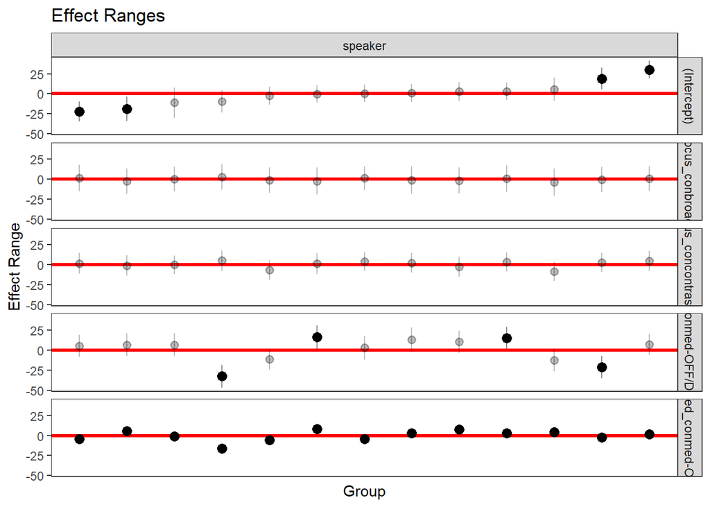

```r
randoms <- REsim(mdl3)
plotREsim(randoms)
```

Plot estimated 95 % interval spans for the intercept of TB velocity

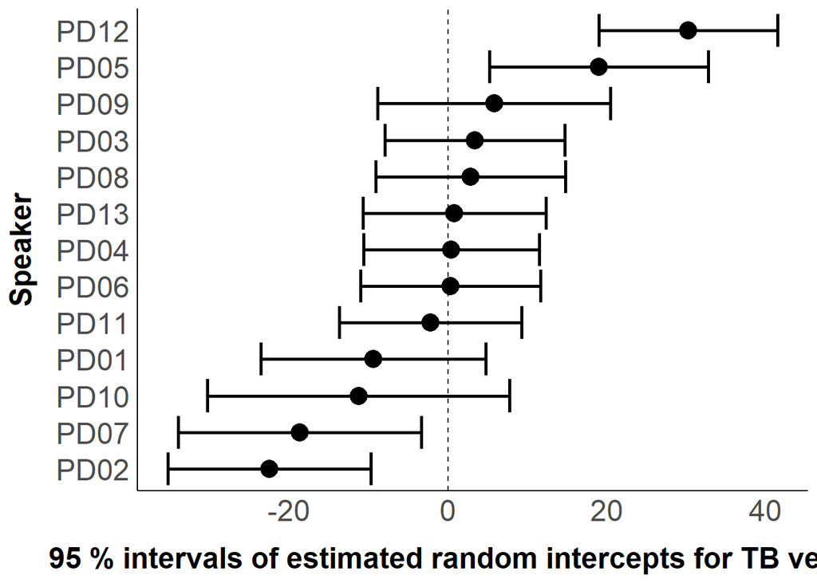

```r
random2 <- subset(randoms, term == "(Intercept)")

random2 %>%
  ggplot(aes(x = mean, xmin = mean-sd-sd, xmax = mean+sd+sd, y = reorder(groupID, mean))) +
  geom_vline(xintercept = 0, linetype = 'dashed') +
  geom_point(size = 5)+
  geom_errorbar(size = 1) +
  theme_classic()+
  xlab('95 % intervals of estimated random intercepts for TB velocity') +
  ylab('Speaker')+
  theme(axis.title.y = element_text(face = 'bold', size = 18, margin = margin(r = 12)))+
  theme(axis.title.x = element_text(face = 'bold', size = 18, margin = margin(t = 12)))+
  theme(strip.text.x = element_text(size=18, face="bold"),
        strip.background = element_blank())+
  theme(axis.text.x = element_text(size = 18),
        axis.text.y = element_text(size = 18)) +
  theme(axis.ticks.x = element_blank(),
        axis.ticks.y = element_blank())+
  theme(legend.position = "top",
        legend.title = element_blank(),
        legend.text = element_text(size = 18))
```

Plot estimated 95 % interval spans for the slopes of TB velocity

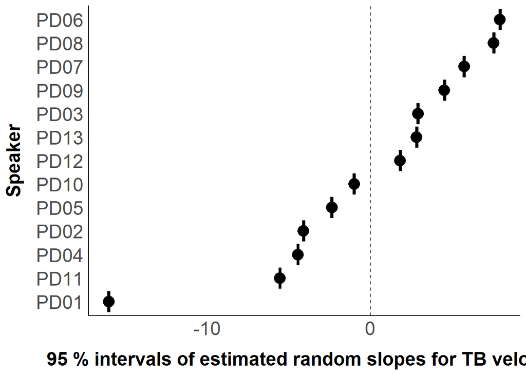

```r
random3 <- subset(randoms, term == "med_conmed-ON")

random3 %>%
  ggplot(aes(x = mean, xmin = mean-sd-sd, xmax = mean+sd+sd, y = reorder(groupID, mean))) +
  geom_vline(xintercept = 0, linetype = 'dashed') +
  geom_point(size = 5)+
  geom_errorbar(size = 1) +
  theme_classic()+
  xlab('95 % intervals of estimated random slopes for TB velocity') +
  ylab('Speaker')+
  theme(axis.title.y = element_text(face = 'bold', size = 18, margin = margin(r = 12)))+
  theme(axis.title.x = element_text(face = 'bold', size = 18, margin = margin(t = 12)))+
  theme(strip.text.x = element_text(size=18, face="bold"),
        strip.background = element_blank())+
  theme(axis.text.x = element_text(size = 18),
        axis.text.y = element_text(size = 18)) +
  theme(axis.ticks.x = element_blank(),
        axis.ticks.y = element_blank())+
  theme(legend.position = "top",
        legend.title = element_blank(),
        legend.text = element_text(size = 18))
```

# Movement Profiles

Descriptive stats for reporting values in Table 7.2

Subset for production of vowels /a/ and /i/

```r
data_red_i_a <-  filter(data_red, vowel %in% c('i', 'a'))
```

Acceleration phase

```r
ACC_stats <- data_red_i_a %>%
  group_by(med_con) %>%
  summarise(M = round(mean(acc_V1)),
            SD = round(sd(acc_V1)))
ACC_stats
```

```
## # A tibble: 3 x 3
##   med_con            M    SD
##   <chr>          <dbl> <dbl>
## 1 med-OFF           99    35
## 2 med-OFF/DBS-ON   100    40
## 3 med-ON            92    32
```

```r
ACC_stats2 <- data_red_i_a %>%
  group_by(med_con, focus_con) %>%
  summarise(M = round(mean(acc_V1)),
            SD = round(sd(acc_V1)))
ACC_stats2
```

```
## # A tibble: 9 x 4
## # Groups:   med_con [3]
##   med_con        focus_con       M    SD
##   <chr>          <chr>       <dbl> <dbl>
## 1 med-OFF        background     95    34
## 2 med-OFF        broad         102    39
## 3 med-OFF        contrastive    99    31
## 4 med-OFF/DBS-ON background     98    36
## 5 med-OFF/DBS-ON broad         101    44
## 6 med-OFF/DBS-ON contrastive   103    41
## 7 med-ON         background     91    31
## 8 med-ON         broad          94    35
## 9 med-ON         contrastive    91    30
```

Deceleration phase

```r
DEC_stats <- data_red_i_a %>%
  group_by(med_con) %>%
  summarise(M = round(mean(dec_V1)),
            SD = round(sd(dec_V1)))
DEC_stats
```

```
## # A tibble: 3 x 3
##   med_con            M    SD
##   <chr>          <dbl> <dbl>
## 1 med-OFF          103    35
## 2 med-OFF/DBS-ON   106    38
## 3 med-ON           100    36
```

```r
DEC_stats2 <- data_red_i_a %>%
  group_by(med_con, focus_con) %>%
  summarise(M = round(mean(dec_V1)),
            SD = round(sd(dec_V1)))
DEC_stats2
```

```
## # A tibble: 9 x 4
## # Groups:   med_con [3]
##   med_con        focus_con       M    SD
##   <chr>          <chr>       <dbl> <dbl>
## 1 med-OFF        background     98    33
## 2 med-OFF        broad         102    33
## 3 med-OFF        contrastive   109    39
## 4 med-OFF/DBS-ON background    101    31
## 5 med-OFF/DBS-ON broad         107    39
## 6 med-OFF/DBS-ON contrastive   111    43
## 7 med-ON         background     93    28
## 8 med-ON         broad         100    35
## 9 med-ON         contrastive   108    42
```

Symmetry profile

```r
SYMM_stats <- data_red_i_a %>%
  group_by(med_con) %>%
  summarise(M = round(mean(symmetry_V1),1),
            SD = round(sd(symmetry_V1),1))
SYMM_stats
```

```
## # A tibble: 3 x 3
##   med_con            M    SD
##   <chr>          <dbl> <dbl>
## 1 med-OFF          1.2   0.6
## 2 med-OFF/DBS-ON   1.2   0.7
## 3 med-ON           1.2   0.6
```

```r
SYMM_stats2 <- data_red_i_a %>%
  group_by(med_con, focus_con) %>%
  summarise(M = round(mean(symmetry_V1),1),
            SD = round(sd(symmetry_V1),1))
SYMM_stats2
```

```
## # A tibble: 9 x 4
## # Groups:   med_con [3]
##   med_con        focus_con       M    SD
##   <chr>          <chr>       <dbl> <dbl>
## 1 med-OFF        background    1.2   0.6
## 2 med-OFF        broad         1.2   0.6
## 3 med-OFF        contrastive   1.3   0.7
## 4 med-OFF/DBS-ON background    1.2   0.7
## 5 med-OFF/DBS-ON broad         1.3   0.8
## 6 med-OFF/DBS-ON contrastive   1.3   0.7
## 7 med-ON         background    1.2   0.5
## 8 med-ON         broad         1.2   0.7
## 9 med-ON         contrastive   1.3   0.7
```

Stiffness

```r
STIFF_stats <- data_red_i_a %>%
  group_by(med_con) %>%
  summarise(M = round(mean(stiffness_V1_abs),1),
            SD = round(sd(stiffness_V1_abs),1))
STIFF_stats
```

```
## # A tibble: 3 x 3
##   med_con            M    SD
##   <chr>          <dbl> <dbl>
## 1 med-OFF          9.3   2
## 2 med-OFF/DBS-ON   9.7   2.7
## 3 med-ON           9.8   2.1
```

```r
STIFF_stats2 <- data_red_i_a %>%
  group_by(med_con, focus_con) %>%
  summarise(M = round(mean(stiffness_V1_abs),1),
            SD = round(sd(stiffness_V1_abs),1))
STIFF_stats2
```

```
## # A tibble: 9 x 4
## # Groups:   med_con [3]
##   med_con        focus_con       M    SD
##   <chr>          <chr>       <dbl> <dbl>
## 1 med-OFF        background    9.7   1.9
## 2 med-OFF        broad         9.3   2.1
## 3 med-OFF        contrastive   9     2.1
## 4 med-OFF/DBS-ON background    9.9   2.4
## 5 med-OFF/DBS-ON broad         9.9   3
## 6 med-OFF/DBS-ON contrastive   9.3   2.7
## 7 med-ON         background   10     2
## 8 med-ON         broad         9.6   2.1
## 9 med-ON         contrastive   9.6   2.3
```

# Timing pattern

```r
ONS_avgs <- data_red %>%
  group_by(med_con) %>%
  summarise(M = round(mean(onsC1_to_onsV1)),
            SD = round(sd(onsC1_to_onsV1)))
ONS_avgs
```

```
## # A tibble: 3 x 3
##   med_con            M    SD
##   <chr>          <dbl> <dbl>
## 1 med-OFF           27    36
## 2 med-OFF/DBS-ON    24    34
## 3 med-ON            28    34
```

```r
TARG_avgs <- data_red %>%
  group_by(med_con) %>%
  summarise(M = round(mean(targC1_to_targV1)),
            SD = round(sd(targC1_to_targV1)))
TARG_avgs
```

```
## # A tibble: 3 x 3
##   med_con            M    SD
##   <chr>          <dbl> <dbl>
## 1 med-OFF          119    37
## 2 med-OFF/DBS-ON   122    36
## 3 med-ON           115    38
```

```r
OnsAlign_avgs <- data_red %>%
  group_by(med_con) %>%
  summarise(M = round(mean(onsV1.syll.dur),2)*100,
            SD = round(sd(onsV1.syll.dur),2)*100)
OnsAlign_avgs
```

```
## # A tibble: 3 x 3
##   med_con            M    SD
##   <chr>          <dbl> <dbl>
## 1 med-OFF          -19    17
## 2 med-OFF/DBS-ON   -18    14
## 3 med-ON           -17    14
```

```r
TargAlign_avgs <- data_red %>%
  group_by(med_con) %>%
  summarise(M = round(mean(targV1.syll.dur),2)*100,
            SD = round(sd(targV1.syll.dur),2)*100)
TargAlign_avgs
```

```
## # A tibble: 3 x 3
##   med_con            M    SD
##   <chr>          <dbl> <dbl>
## 1 med-OFF           69    11
## 2 med-OFF/DBS-ON    68     9
## 3 med-ON            68    11
```

Statistical analysis for timing patterns

create model for onset to onset interval

```r
mdl4 <- lmer(onsC1_to_onsV1 ~ med_con + focus_con + vowel + cons + age  + (1 + focus_con+med_con|speaker), data_red, REML = FALSE)
```

Look at model

```r
summary(mdl4)
```

```
## Linear mixed model fit by maximum likelihood . t-tests use Satterthwaite's
##   method [lmerModLmerTest]
## Formula: onsC1_to_onsV1 ~ med_con + focus_con + vowel + cons + age + (1 +
##     focus_con + med_con | speaker)
##    Data: data_red
##
##      AIC      BIC   logLik deviance df.resid
##  11386.5  11523.4  -5666.2  11332.5     1150
##
## Scaled residuals:
##     Min      1Q  Median      3Q     Max
## -2.5340 -0.6625 -0.0502  0.5966  9.1649
##
## Random effects:
##  Groups   Name                  Variance Std.Dev. Corr
##  speaker  (Intercept)           162.144  12.734
##           focus_conbroad         16.619   4.077    0.40
##           focus_concontrastive    4.716   2.172    0.28  0.95
##           med_conmed-OFF/DBS-ON 114.811  10.715   -0.85 -0.57 -0.60
##           med_conmed-ON          23.443   4.842    0.27 -0.71 -0.63 -0.18
##  Residual                       851.744  29.185
## Number of obs: 1177, groups:  speaker, 13
##
## Fixed effects:
##                        Estimate Std. Error        df t value Pr(>|t|)
## (Intercept)             23.3335    17.2709   14.5263   1.351    0.197
## med_conmed-OFF/DBS-ON   -2.8079     3.6380   13.4432  -0.772    0.454
## med_conmed-ON            0.6545     2.4800   17.3420   0.264    0.795
## focus_conbroad           2.9570     2.3686   21.7656   1.248    0.225
## focus_concontrastive     2.6815     2.1676   69.4786   1.237    0.220
## vowele                  12.3945     2.6767 1138.7699   4.630 4.07e-06 ***
## voweli                  -2.2726     2.7048 1138.6267  -0.840    0.401
## vowelo                  -0.8038     2.6984 1138.2983  -0.298    0.766
## vowelu                  24.9894     2.6955 1138.2129   9.271  < 2e-16 ***
## conslab                 16.7996     1.7017 1138.7103   9.872  < 2e-16 ***
## age                     -0.2286     0.2832   13.1820  -0.807    0.434
## ---
## Signif. codes:  0 '***' 0.001 '**' 0.01 '*' 0.05 '.' 0.1 ' ' 1
##
## Correlation of Fixed Effects:
```

[output cut: 9 more lines]

```
## conslab     -0.051  0.003  0.005  0.003   0.002   0.000 -0.005 -0.005 -0.004
## age         -0.966 -0.068 -0.001  0.001   0.003   0.000 -0.003  0.001  0.001
##             conslb
## m_-OFF/DBS-
## med_cnmd-ON
## focus_cnbrd
## fcs_cncntrs
## vowele
## voweli
## vowelo
## vowelu
## conslab
## age          0.002
## optimizer (nloptwrap) convergence code: 0 (OK)
## boundary (singular) fit: see help('isSingular')
```

Extracting fit statistics for reporting in text

```r
tab_model(mdl4)
```

|  | ons C 1 to ons V 1 |  |  |
| --- | --- | --- | --- |
| Predictors | Estimates | CI | p |
| (Intercept) | 23.33 | -10.55 – 57.22 | 0.177 |
| med con [med-OFF/DBS-ON] | -2.81 | -9.95 – 4.33 | 0.440 |
| med con [med-ON] | 0.65 | -4.21 – 5.52 | 0.792 |
| focus con [broad] | 2.96 | -1.69 – 7.60 | 0.212 |
| focus con [contrastive] | 2.68 | -1.57 – 6.93 | 0.216 |
| vowel [e] | 12.39 | 7.14 – 17.65 | **<0.001** |
| vowel [i] | -2.27 | -7.58 – 3.03 | 0.401 |
| vowel [o] | -0.80 | -6.10 – 4.49 | 0.766 |
| vowel [u] | 24.99 | 19.70 – 30.28 | **<0.001** |
| cons [lab] | 16.80 | 13.46 – 20.14 | **<0.001** |
| age | -0.23 | -0.78 – 0.33 | 0.420 |
| Random Effects |  |  |  |
| σ<sup>2</sup> | 851.74 |  |  |
| τ<sub>00</sub> <sub>speaker</sub> | 162.14 |  |  |
| τ<sub>11</sub> <sub>speaker.focus_conbroad</sub> | 16.62 |  |  |
| τ<sub>11</sub> <sub>speaker.focus_concontrastive</sub> | 4.72 |  |  |
| τ<sub>11</sub> <sub>speaker.med_conmed-OFF/DBS-ON</sub> | 114.81 |  |  |
| τ<sub>11</sub> <sub>speaker.med_conmed-ON</sub> | 23.44 |  |  |
| ρ<sub>01</sub> | 0.40 |  |  |
|  | 0.28 |  |  |
|  | -0.85 |  |  |
|  | 0.27 |  |  |
| N <sub>speaker</sub> | 13 |  |  |
| Observations | 1177 |  |  |
| Marginal R<sup>2</sup> / Conditional R<sup>2</sup> | 0.181 / NA |  |  |

create model for target to target interval

```r
mdl5 <- lmer(targC1_to_targV1 ~ med_con + focus_con + vowel + cons + age  + (1 + focus_con+med_con|speaker), data_red, REML = FALSE)
```

Look at model

```r
summary(mdl5)
```

```
## Linear mixed model fit by maximum likelihood . t-tests use Satterthwaite's
##   method [lmerModLmerTest]
## Formula: targC1_to_targV1 ~ med_con + focus_con + vowel + cons + age +
##     (1 + focus_con + med_con | speaker)
##    Data: data_red
##
##      AIC      BIC   logLik deviance df.resid
##  11191.3  11328.2  -5568.6  11137.3     1150
##
## Scaled residuals:
##     Min      1Q  Median      3Q     Max
## -3.3973 -0.6247 -0.0362  0.5860  5.2087
##
## Random effects:
##  Groups   Name                  Variance Std.Dev. Corr
##  speaker  (Intercept)           334.92   18.301
##           focus_conbroad         15.85    3.981    0.94
##           focus_concontrastive   28.07    5.298    0.86  0.64
##           med_conmed-OFF/DBS-ON 246.40   15.697   -0.19 -0.48  0.30
##           med_conmed-ON          86.00    9.274    0.11 -0.04  0.31  0.72
##  Residual                       699.43   26.447
## Number of obs: 1177, groups:  speaker, 13
##
## Fixed effects:
##                       Estimate Std. Error       df t value Pr(>|t|)
## (Intercept)             59.768     34.172   16.037   1.749 0.099396 .
## med_conmed-OFF/DBS-ON    2.767      4.771   13.227   0.580 0.571682
## med_conmed-ON           -4.027      3.192   13.119  -1.262 0.229033
## focus_conbroad           9.121      2.186   27.178   4.173 0.000277 ***
## focus_concontrastive    13.670      2.392   19.868   5.716 1.39e-05 ***
## vowele                 -17.743      2.426 1137.858  -7.315 4.84e-13 ***
## voweli                 -32.801      2.451 1137.894 -13.382  < 2e-16 ***
## vowelo                 -19.379      2.445 1137.628  -7.925 5.41e-15 ***
## vowelu                 -17.691      2.443 1137.577  -7.243 8.09e-13 ***
## conslab                 -5.120      1.542 1137.821  -3.320 0.000928 ***
## age                      1.210      0.572   15.856   2.116 0.050511 .
## ---
## Signif. codes:  0 '***' 0.001 '**' 0.01 '*' 0.05 '.' 0.1 ' ' 1
##
## Correlation of Fixed Effects:
```

[output cut: 9 more lines]

```
## conslab     -0.029  0.001  0.004  0.003   0.002   0.000 -0.005 -0.005 -0.004
## age         -0.986 -0.102 -0.002  0.002   0.003  -0.004 -0.007 -0.005 -0.001
##             conslb
## m_-OFF/DBS-
## med_cnmd-ON
## focus_cnbrd
## fcs_cncntrs
## vowele
## voweli
## vowelo
## vowelu
## conslab
## age          0.006
## optimizer (nloptwrap) convergence code: 0 (OK)
## boundary (singular) fit: see help('isSingular')
```

Extracting fit statistics for reporting in text

```r
tab_model(mdl5)
```

|  | targ C 1 to targ V 1 |  |  |
| --- | --- | --- | --- |
| Predictors | Estimates | CI | p |
| (Intercept) | 59.77 | -7.28 – 126.82 | 0.081 |
| med con [med-OFF/DBS-ON] | 2.77 | -6.59 – 12.13 | 0.562 |
| med con [med-ON] | -4.03 | -10.29 – 2.24 | 0.207 |
| focus con [broad] | 9.12 | 4.83 – 13.41 | **<0.001** |
| focus con [contrastive] | 13.67 | 8.98 – 18.36 | **<0.001** |
| vowel [e] | -17.74 | -22.50 – -12.98 | **<0.001** |
| vowel [i] | -32.80 | -37.61 – -27.99 | **<0.001** |
| vowel [o] | -19.38 | -24.18 – -14.58 | **<0.001** |
| vowel [u] | -17.69 | -22.48 – -12.90 | **<0.001** |
| cons [lab] | -5.12 | -8.15 – -2.09 | **0.001** |
| age | 1.21 | 0.09 – 2.33 | **0.035** |
| Random Effects |  |  |  |
| σ<sup>2</sup> | 699.43 |  |  |
| τ<sub>00</sub> <sub>speaker</sub> | 334.92 |  |  |
| τ<sub>11</sub> <sub>speaker.focus_conbroad</sub> | 15.85 |  |  |
| τ<sub>11</sub> <sub>speaker.focus_concontrastive</sub> | 28.07 |  |  |
| τ<sub>11</sub> <sub>speaker.med_conmed-OFF/DBS-ON</sub> | 246.40 |  |  |
| τ<sub>11</sub> <sub>speaker.med_conmed-ON</sub> | 86.00 |  |  |
| ρ<sub>01</sub> | 0.94 |  |  |
|  | 0.86 |  |  |
|  | -0.19 |  |  |
|  | 0.11 |  |  |
| N <sub>speaker</sub> | 13 |  |  |
| Observations | 1177 |  |  |
| Marginal R<sup>2</sup> / Conditional R<sup>2</sup> | 0.265 / NA |  |  |

create model for onset alignment

```r
mdl6 <- lmer(onsV1.syll.dur ~ med_con + focus_con + vowel + cons + age  + (1 + focus_con+med_con|speaker), data_red, REML = FALSE)
```

Look at model

```r
summary(mdl6)
```

```
## Linear mixed model fit by maximum likelihood . t-tests use Satterthwaite's
##   method [lmerModLmerTest]
## Formula: onsV1.syll.dur ~ med_con + focus_con + vowel + cons + age + (1 +
##     focus_con + med_con | speaker)
##    Data: data_red
##
##      AIC      BIC   logLik deviance df.resid
##  -1482.9  -1346.0    768.4  -1536.9     1150
##
## Scaled residuals:
##     Min      1Q  Median      3Q     Max
## -7.2455 -0.6672  0.0228  0.6634  3.1640
##
## Random effects:
##  Groups   Name                  Variance  Std.Dev. Corr
##  speaker  (Intercept)           0.0054564 0.07387
##           focus_conbroad        0.0001246 0.01116   0.11
##           focus_concontrastive  0.0002199 0.01483  -0.97  0.12
##           med_conmed-OFF/DBS-ON 0.0018590 0.04312  -0.99 -0.24  0.94
##           med_conmed-ON         0.0019957 0.04467  -0.46  0.83  0.65  0.34
##  Residual                       0.0151579 0.12312
## Number of obs: 1177, groups:  speaker, 13
##
## Fixed effects:
##                         Estimate Std. Error         df t value Pr(>|t|)
## (Intercept)           -2.758e-01  6.629e-02  3.321e+01  -4.160 0.000211 ***
## med_conmed-OFF/DBS-ON  1.773e-02  1.487e-02  1.457e+01   1.192 0.252226
## med_conmed-ON          2.208e-02  1.519e-02  1.319e+01   1.453 0.169519
## focus_conbroad         1.972e-02  9.310e-03  5.396e+01   2.118 0.038833 *
## focus_concontrastive   3.366e-02  9.700e-03  3.691e+01   3.471 0.001339 **
## vowele                 2.275e-02  1.129e-02  1.151e+03   2.015 0.044179 *
## voweli                -5.712e-02  1.141e-02  1.151e+03  -5.006 6.43e-07 ***
## vowelo                -1.513e-02  1.138e-02  1.151e+03  -1.329 0.184062
## vowelu                 8.503e-02  1.137e-02  1.151e+03   7.477 1.50e-13 ***
## conslab                9.165e-02  7.178e-03  1.151e+03  12.768  < 2e-16 ***
## age                    1.484e-04  1.052e-03  2.832e+01   0.141 0.888812
## ---
## Signif. codes:  0 '***' 0.001 '**' 0.01 '*' 0.05 '.' 0.1 ' ' 1
##
## Correlation of Fixed Effects:
```

[output cut: 9 more lines]

```
## conslab     -0.055  0.003  0.004  0.003   0.002   0.000 -0.006 -0.005 -0.004
## age         -0.935 -0.063 -0.001  0.002   0.003   0.001  0.000  0.004  0.002
##             conslb
## m_-OFF/DBS-
## med_cnmd-ON
## focus_cnbrd
## fcs_cncntrs
## vowele
## voweli
## vowelo
## vowelu
## conslab
## age          0.001
## optimizer (nloptwrap) convergence code: 0 (OK)
## boundary (singular) fit: see help('isSingular')
```

Extracting fit statistics for reporting in text

```r
tab_model(mdl6)
```

|  | ons V 1.syll dur |  |  |
| --- | --- | --- | --- |
| Predictors | Estimates | CI | p |
| (Intercept) | -0.28 | -0.41 – -0.15 | **<0.001** |
| med con [med-OFF/DBS-ON] | 0.02 | -0.01 – 0.05 | 0.233 |
| med con [med-ON] | 0.02 | -0.01 – 0.05 | 0.146 |
| focus con [broad] | 0.02 | 0.00 – 0.04 | **0.034** |
| focus con [contrastive] | 0.03 | 0.01 – 0.05 | **0.001** |
| vowel [e] | 0.02 | 0.00 – 0.04 | **0.044** |
| vowel [i] | -0.06 | -0.08 – -0.03 | **<0.001** |
| vowel [o] | -0.02 | -0.04 – 0.01 | 0.184 |
| vowel [u] | 0.09 | 0.06 – 0.11 | **<0.001** |
| cons [lab] | 0.09 | 0.08 – 0.11 | **<0.001** |
| age | 0.00 | -0.00 – 0.00 | 0.888 |
| Random Effects |  |  |  |
| σ<sup>2</sup> | 0.02 |  |  |
| τ<sub>00</sub> <sub>speaker</sub> | 0.01 |  |  |
| τ<sub>11</sub> <sub>speaker.focus_conbroad</sub> | 0.00 |  |  |
| τ<sub>11</sub> <sub>speaker.focus_concontrastive</sub> | 0.00 |  |  |
| τ<sub>11</sub> <sub>speaker.med_conmed-OFF/DBS-ON</sub> | 0.00 |  |  |
| τ<sub>11</sub> <sub>speaker.med_conmed-ON</sub> | 0.00 |  |  |
| ρ<sub>01</sub> | 0.11 |  |  |
|  | -0.97 |  |  |
|  | -0.99 |  |  |
|  | -0.46 |  |  |
| ICC | 0.18 |  |  |
| N <sub>speaker</sub> | 13 |  |  |
| Observations | 1177 |  |  |
| Marginal R<sup>2</sup> / Conditional R<sup>2</sup> | 0.197 / 0.343 |  |  |

create model for target alignment

```r
mdl7 <- lmer(targV1.syll.dur ~ med_con + focus_con + vowel + cons + age + (1 + focus_con+med_con|speaker), data_red, REML = FALSE)
```

Look at model

```r
summary(mdl7)
```

```
## Linear mixed model fit by maximum likelihood . t-tests use Satterthwaite's
##   method [lmerModLmerTest]
## Formula: targV1.syll.dur ~ med_con + focus_con + vowel + cons + age +
##     (1 + focus_con + med_con | speaker)
##    Data: data_red
##
##      AIC      BIC   logLik deviance df.resid
##  -2204.9  -2068.0   1129.4  -2258.9     1150
##
## Scaled residuals:
##     Min      1Q  Median      3Q     Max
## -3.9682 -0.5849  0.0222  0.5847  4.6986
##
## Random effects:
##  Groups   Name                  Variance  Std.Dev. Corr
##  speaker  (Intercept)           0.0008116 0.028489
##           focus_conbroad        0.0000412 0.006418 -0.85
##           focus_concontrastive  0.0001280 0.011314 -0.02  0.32
##           med_conmed-OFF/DBS-ON 0.0006512 0.025519 -0.68  0.21 -0.27
##           med_conmed-ON         0.0002059 0.014348 -0.24  0.59  0.95 -0.25
##  Residual                       0.0083022 0.091117
## Number of obs: 1177, groups:  speaker, 13
##
## Fixed effects:
##                         Estimate Std. Error         df t value Pr(>|t|)
## (Intercept)            6.166e-01  4.244e-02  1.537e+01  14.527 2.17e-10 ***
## med_conmed-OFF/DBS-ON -5.793e-03  9.632e-03  1.345e+01  -0.601 0.557593
## med_conmed-ON         -6.697e-03  7.630e-03  1.656e+01  -0.878 0.392641
## focus_conbroad         2.424e-03  6.737e-03  8.248e+01   0.360 0.719937
## focus_concontrastive   1.874e-03  7.219e-03  2.254e+01   0.260 0.797579
## vowele                 5.648e-02  8.356e-03  1.138e+03   6.759 2.21e-11 ***
## voweli                 5.428e-02  8.444e-03  1.138e+03   6.428 1.90e-10 ***
## vowelo                -3.136e-02  8.425e-03  1.138e+03  -3.722 0.000207 ***
## vowelu                 7.267e-02  8.415e-03  1.138e+03   8.635  < 2e-16 ***
## conslab               -2.039e-02  5.313e-03  1.138e+03  -3.838 0.000131 ***
## age                    8.353e-04  6.927e-04  1.373e+01   1.206 0.248241
## ---
## Signif. codes:  0 '***' 0.001 '**' 0.01 '*' 0.05 '.' 0.1 ' ' 1
##
## Correlation of Fixed Effects:
```

[output cut: 9 more lines]

```
## conslab     -0.062  0.004  0.005  0.003   0.002   0.000 -0.005 -0.005 -0.004
## age         -0.962 -0.063  0.002  0.003   0.002   0.005 -0.002  0.001  0.002
##             conslb
## m_-OFF/DBS-
## med_cnmd-ON
## focus_cnbrd
## fcs_cncntrs
## vowele
## voweli
## vowelo
## vowelu
## conslab
## age         -0.001
## optimizer (nloptwrap) convergence code: 0 (OK)
## boundary (singular) fit: see help('isSingular')
```

Extracting fit statistics for reporting in text

```r
tab_model(mdl7)
```

|  | targ V 1.syll dur |  |  |
| --- | --- | --- | --- |
| Predictors | Estimates | CI | p |
| (Intercept) | 0.62 | 0.53 – 0.70 | **<0.001** |
| med con [med-OFF/DBS-ON] | -0.01 | -0.02 – 0.01 | 0.548 |
| med con [med-ON] | -0.01 | -0.02 – 0.01 | 0.380 |
| focus con [broad] | 0.00 | -0.01 – 0.02 | 0.719 |
| focus con [contrastive] | 0.00 | -0.01 – 0.02 | 0.795 |
| vowel [e] | 0.06 | 0.04 – 0.07 | **<0.001** |
| vowel [i] | 0.05 | 0.04 – 0.07 | **<0.001** |
| vowel [o] | -0.03 | -0.05 – -0.01 | **<0.001** |
| vowel [u] | 0.07 | 0.06 – 0.09 | **<0.001** |
| cons [lab] | -0.02 | -0.03 – -0.01 | **<0.001** |
| age | 0.00 | -0.00 – 0.00 | 0.228 |
| Random Effects |  |  |  |
| σ<sup>2</sup> | 0.01 |  |  |
| τ<sub>00</sub> <sub>speaker</sub> | 0.00 |  |  |
| τ<sub>11</sub> <sub>speaker.focus_conbroad</sub> | 0.00 |  |  |
| τ<sub>11</sub> <sub>speaker.focus_concontrastive</sub> | 0.00 |  |  |
| τ<sub>11</sub> <sub>speaker.med_conmed-OFF/DBS-ON</sub> | 0.00 |  |  |
| τ<sub>11</sub> <sub>speaker.med_conmed-ON</sub> | 0.00 |  |  |
| ρ<sub>01</sub> | -0.85 |  |  |
|  | -0.02 |  |  |
|  | -0.68 |  |  |
|  | -0.24 |  |  |
| N <sub>speaker</sub> | 13 |  |  |
| Observations | 1177 |  |  |
| Marginal R<sup>2</sup> / Conditional R<sup>2</sup> | 0.171 / NA |  |  |